# Analysis of longitudinal data - week 6

## Analysis of RATS data

- According to chapter 8 from MABS

```r
setwd("D:/New folder/OneDrive for Business 1/Git/IODS/IODS-project/data")
RATSL <- read.table(file = "RATSL.txt",
                           header = TRUE,
                           dec = ".")
RATSL$ID <- factor(RATSL$ID)
RATSL$Group <- factor(RATSL$Group)
str(RATSL)
```

```
## 'data.frame':    176 obs. of  5 variables:
##  $ ID    : Factor w/ 16 levels "1","2","3","4",..: 1 2 3 4 5 6 7 8 9 10 ...
##  $ Group : Factor w/ 3 levels "1","2","3": 1 1 1 1 1 1 1 1 2 2 ...
##  $ WD    : Factor w/ 11 levels "WD1","WD15","WD22",..: 1 1 1 1 1 1 1 1 1 1 ...
##  $ Weight: int  240 225 245 260 255 260 275 245 410 405 ...
##  $ Time  : int  1 1 1 1 1 1 1 1 1 1 ...
```

### Libraries

```r
library(dplyr)
```

```r
library(ggplot2)
library(lme4)
```

### Data exploration

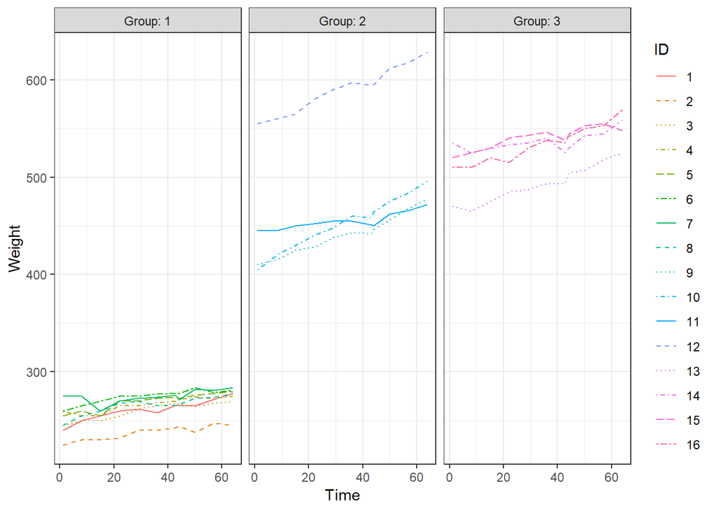

```r
ggplot(RATSL, aes(x = Time, y = Weight, linetype = ID)) +
  geom_line() +
  scale_linetype_manual(values = rep(1:10, times=4)) +
  facet_grid(. ~ Group, labeller = label_both) +
  theme_bw() +geom_line(aes(color=ID))+
  scale_y_continuous(limits = c(min(RATSL$Weight), max(RATSL$Weight)))
```

This graph shows the individual weight of subjects by treatment group. The weight seems to generally inrease with time for individuals in every group treatment. One individual from each group seems to either have higher or lower weight compared to individuals of the same group. From the graph You can notice that their initial weight was already very different compared to other individuals. This shows that individuals’ starting weight should be taken into account when quantifying the treatment effects. There are more individuals in group 1, and they appear to have the lowest weight.

Lets see if we can visualize the variability better with standardized data.

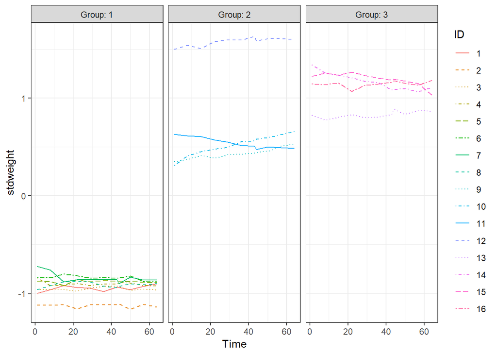

```r
RATSL <- RATSL %>%
  group_by(Time) %>%
  mutate(stdweight = (Weight - mean(Weight))/sd(Weight)) %>%
  ungroup()


ggplot(RATSL, aes(x = Time, y = stdweight, linetype = ID)) +
  geom_line() +
  scale_linetype_manual(values = rep(1:10, times=4)) +
  facet_grid(. ~ Group, labeller = label_both) +
  theme_bw() +geom_line(aes(color=ID))+
  scale_y_continuous(limits = c(min(RATSL$stdweight), max(RATSL$stdweight)))
```

Shows what we already knew.

Let’s now plot the mean effect of the 3 treatments in time.

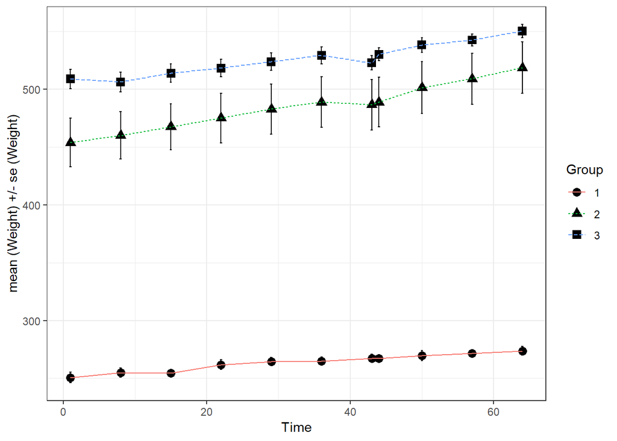

```r
n <- RATSL$Time %>% unique() %>% length()

# Summary data with mean and standard error of Weight by Group and Time
df <- RATSL %>%
  group_by(Group, Time) %>%
  summarise( mean = mean(Weight), se = sd(Weight)/sqrt(n)) %>%
  ungroup()


ggplot(df, aes(x = Time, y = mean, linetype = Group, shape = Group)) +
  geom_line() +
  geom_point(size=3) +
  geom_errorbar(aes(ymin=mean-se, ymax=mean+se, linetype="1"), width=0.3) +
  theme(legend.position = c(0.8,0.8)) + theme_bw() + geom_line(aes(color=Group))+
  scale_y_continuous(name = "mean (Weight) +/- se (Weight)")
```

Time for a quick and dirty analysis. Let’s average the all repeated observations taken from individual, so we “capture” the general effect of time in each individual.

```r
df1 <- RATSL %>%
    group_by(Group, ID) %>%
  summarise( mean=mean(Weight) ) %>%
  ungroup()
```

We can visualize the differences between groups directly.

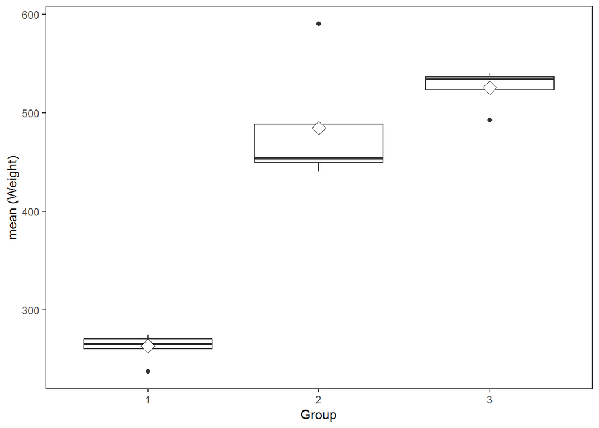

```r
ggplot(df1, aes(x = Group, y = mean))+
geom_boxplot()+
theme_bw() + theme(panel.grid.major = element_blank(), panel.grid.minor = element_blank())+
stat_summary(fun.y = "mean", geom = "point", shape=23, size=4, fill = "white")+
scale_y_continuous(name = "mean (Weight)")
```

Based on this graph, it looks like there’s an outlier in group 2. I wouldn’t remove it as there are too few variables (n=16). I think that the linear mixed model in this scenario would be able to take into account the specific variance between individuals.

Now we fit the linear model

```r
fitRATS <- lm(mean ~ Group, data = df1)
anova(fitRATS)
```

```
## Analysis of Variance Table
##
## Response: mean
##           Df Sum Sq Mean Sq F value    Pr(>F)
## Group      2 236732  118366  88.073 2.763e-08 ***
## Residuals 13  17471    1344
## ---
## Signif. codes:  0 '***' 0.001 '**' 0.01 '*' 0.05 '.' 0.1 ' ' 1
```

From the anova table we see that the group variable (reflecting treatments) significantly affects the weight of the rats.

```r
summary(fitRATS)
```

```
##
## Call:
## lm(formula = mean ~ Group, data = df1)
##
## Residuals:
##     Min      1Q  Median      3Q     Max
## -43.886 -27.031   2.284  10.588 105.750
##
## Coefficients:
##             Estimate Std. Error t value Pr(>|t|)
## (Intercept)   263.72      12.96  20.346 3.06e-11 ***
## Group2        220.99      22.45   9.844 2.16e-07 ***
## Group3        262.08      22.45  11.674 2.91e-08 ***
## ---
## Signif. codes:  0 '***' 0.001 '**' 0.01 '*' 0.05 '.' 0.1 ' ' 1
##
## Residual standard error: 36.66 on 13 degrees of freedom
## Multiple R-squared:  0.9313, Adjusted R-squared:  0.9207
## F-statistic: 88.07 on 2 and 13 DF,  p-value: 2.763e-08
```

From the summary table we see that treatment 3 (group 3) produces the highest weights, whereas treatment 1 (group 1) produces the lowest weights.

## Analysis of BPRS data

- According to chapter 9 from MABS

```r
setwd("D:/New folder/OneDrive for Business 1/Git/IODS/IODS-project/data")
BPRSL <- read.table(file = "BPRSL.txt",
                    header = TRUE,
                    dec = ".")
BPRSL$treatment <- factor(BPRSL$treatment)
BPRSL$subject <- factor(BPRSL$subject)
str(BPRSL)
```

```
## 'data.frame':    360 obs. of  5 variables:
##  $ treatment: Factor w/ 2 levels "1","2": 1 1 1 1 1 1 1 1 1 1 ...
##  $ subject  : Factor w/ 20 levels "1","2","3","4",..: 1 2 3 4 5 6 7 8 9 10 ...
##  $ weeks    : Factor w/ 9 levels "week0","week1",..: 1 1 1 1 1 1 1 1 1 1 ...
##  $ bprs     : int  42 58 54 55 72 48 71 30 41 57 ...
##  $ week     : int  0 0 0 0 0 0 0 0 0 0 ...
```

Let’s plot bprs versus the time, ignoring the fact that repeated measurements were done in each individual.

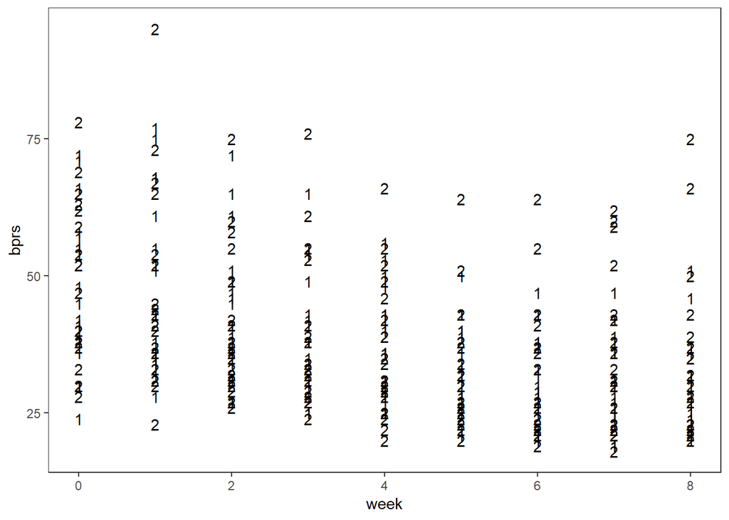

```r
ggplot(BPRSL, aes(x = week, y = bprs, group = subject))+
geom_text(aes(label = treatment))+
scale_y_continuous(name = "bprs")+
theme_bw()+
theme(panel.grid.major = element_blank(), panel.grid.minor = element_blank())
```

It doesn’t look like the treatments differ. To be sure, let’s run a quick linear model.

```r
fitBPRS <- lm(bprs ~ week + treatment, data = BPRSL)
anova(fitBPRS)
```

```
## Analysis of Variance Table
##
## Response: bprs
##            Df Sum Sq Mean Sq F value Pr(>F)
## week        1  12372 12371.5 80.9143 <2e-16 ***
## treatment   1     29    29.5  0.1927 0.6609
## Residuals 357  54584   152.9
## ---
## Signif. codes:  0 '***' 0.001 '**' 0.01 '*' 0.05 '.' 0.1 ' ' 1
```

No evidence was found to say the treatment had an effect on the bprs. However, the week significantly affected (negatively) bprs.

```r
summary(fitBPRS)
```

```
##
## Call:
## lm(formula = bprs ~ week + treatment, data = BPRSL)
##
## Residuals:
##     Min      1Q  Median      3Q     Max
## -22.454  -8.965  -3.196   7.002  50.244
##
## Coefficients:
##             Estimate Std. Error t value Pr(>|t|)
## (Intercept)  46.4539     1.3670  33.982   <2e-16 ***
## week         -2.2704     0.2524  -8.995   <2e-16 ***
## treatment2    0.5722     1.3034   0.439    0.661
## ---
## Signif. codes:  0 '***' 0.001 '**' 0.01 '*' 0.05 '.' 0.1 ' ' 1
##
## Residual standard error: 12.37 on 357 degrees of freedom
## Multiple R-squared:  0.1851, Adjusted R-squared:  0.1806
## F-statistic: 40.55 on 2 and 357 DF,  p-value: < 2.2e-16
```

We can see the coeficients for the model. Treatment 2 had a positive effect on bprs, but non significant.

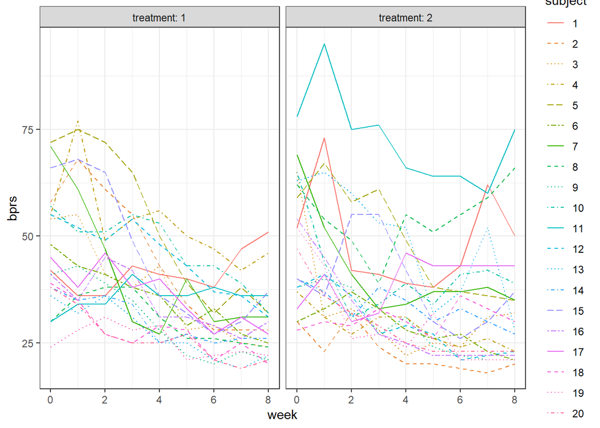

```r
ggplot(BPRSL, aes(x = week, y = bprs, linetype = subject)) +
  geom_line() +
  scale_linetype_manual(values = rep(1:10, times=4)) +
  facet_grid(. ~ treatment, labeller = label_both) +
  theme_bw() +geom_line(aes(color=subject))+
  scale_y_continuous(limits = c(min(BPRSL$bprs), max(BPRSL$bprs)))
```

From this graph we can see there’s a large variability between subjects, making it hard to differenciate treatment effects. But we can indeed see the effect of week.

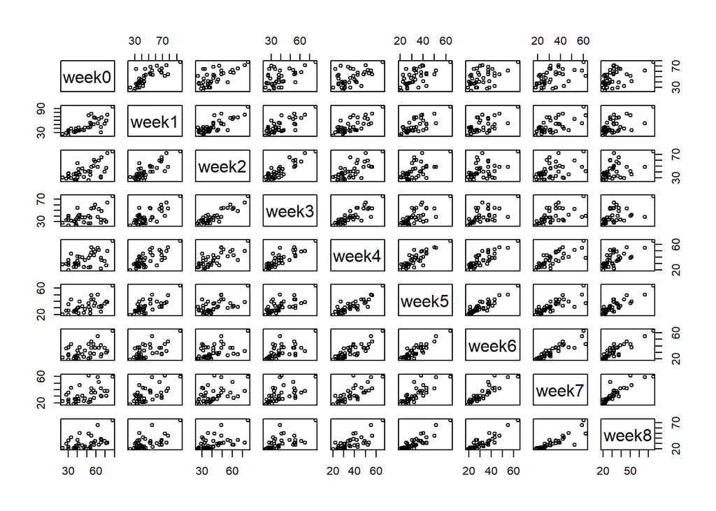

```r
BPRS<-read.table("https://raw.githubusercontent.com/KimmoVehkalahti/MABS/master/Examples/data/BPRS.txt",
                 header=T, sep=" ")
pairs(BPRS[, 3:11], cex = 0.7)
```

The weeks strongly correlate with each other.

Now we fit the linear mixed effect model with individuals as random intercepts, so the model accounts for the variability in subjects.

```r
mixedBPRS <- lmer(bprs ~ week + treatment + (1 | subject), data = BPRSL, REML = FALSE)
summary(mixedBPRS)
```

```
## Linear mixed model fit by maximum likelihood  ['lmerMod']
## Formula: bprs ~ week + treatment + (1 | subject)
##    Data: BPRSL
##
##      AIC      BIC   logLik deviance df.resid
##   2748.7   2768.1  -1369.4   2738.7      355
##
## Scaled residuals:
##     Min      1Q  Median      3Q     Max
## -3.0481 -0.6749 -0.1361  0.4813  3.4855
##
## Random effects:
##  Groups   Name        Variance Std.Dev.
##  subject  (Intercept)  47.41    6.885
##  Residual             104.21   10.208
## Number of obs: 360, groups:  subject, 20
##
## Fixed effects:
##             Estimate Std. Error t value
## (Intercept)  46.4539     1.9090  24.334
## week         -2.2704     0.2084 -10.896
## treatment2    0.5722     1.0761   0.532
##
## Correlation of Fixed Effects:
##            (Intr) week
## week       -0.437
## treatment2 -0.282  0.000
```

The fixed effects were the same found by the linear model, but the mixed model would allow for the intercept to be correct 20 times (one per individual). Ideally, the data should’ve been coded in a way that there would be 40 individuals. Now it thinks that each individual received both treatments, probably imposing some correlation between them. but I am no sure. The standard error is slightly smaller, so we can still try to improve the model by fitting a random intercept and model, so that the slope of each subject can also change according to week.

```r
mixedBPRS1 <- lmer(bprs ~ week + treatment + (week| subject), data = BPRSL, REML = FALSE)
summary(mixedBPRS1)
```

```
## Linear mixed model fit by maximum likelihood  ['lmerMod']
## Formula: bprs ~ week + treatment + (week | subject)
##    Data: BPRSL
##
##      AIC      BIC   logLik deviance df.resid
##   2745.4   2772.6  -1365.7   2731.4      353
##
## Scaled residuals:
##     Min      1Q  Median      3Q     Max
## -2.8919 -0.6194 -0.0691  0.5531  3.7976
##
## Random effects:
##  Groups   Name        Variance Std.Dev. Corr
##  subject  (Intercept) 64.8202  8.0511
##           week         0.9608  0.9802   -0.51
##  Residual             97.4307  9.8707
## Number of obs: 360, groups:  subject, 20
##
## Fixed effects:
##             Estimate Std. Error t value
## (Intercept)  46.4539     2.1052  22.066
## week         -2.2704     0.2977  -7.626
## treatment2    0.5722     1.0405   0.550
##
## Correlation of Fixed Effects:
##            (Intr) week
## week       -0.582
## treatment2 -0.247  0.000
```

Not so much difference. We can compare them by:

```r
anova(mixedBPRS,mixedBPRS1)
```

```
## Data: BPRSL
## Models:
## mixedBPRS: bprs ~ week + treatment + (1 | subject)
## mixedBPRS1: bprs ~ week + treatment + (week | subject)
##            Df    AIC    BIC  logLik deviance  Chisq Chi Df Pr(>Chisq)
## mixedBPRS   5 2748.7 2768.1 -1369.4   2738.7
## mixedBPRS1  7 2745.4 2772.6 -1365.7   2731.4 7.2721      2    0.02636 *
## ---
## Signif. codes:  0 '***' 0.001 '**' 0.01 '*' 0.05 '.' 0.1 ' ' 1
```

According to the likelihood ratio test, the random intercept and slope model is better (LRT=7.27, df=2,p=0.03).

At last, we fit a random intercept and slope model that allows for a treatment × week interaction, so the slope of week will change based on treatment.

```r
mixedBPRS2 <- lmer(bprs ~ week *treatment + (week| subject), data = BPRSL, REML = FALSE)
summary(mixedBPRS2)
```

```
## Linear mixed model fit by maximum likelihood  ['lmerMod']
## Formula: bprs ~ week * treatment + (week | subject)
##    Data: BPRSL
##
##      AIC      BIC   logLik deviance df.resid
##   2744.3   2775.4  -1364.1   2728.3      352
##
## Scaled residuals:
##     Min      1Q  Median      3Q     Max
## -3.0512 -0.6271 -0.0767  0.5288  3.9260
##
## Random effects:
##  Groups   Name        Variance Std.Dev. Corr
##  subject  (Intercept) 65.0016  8.0624
##           week         0.9688  0.9843   -0.51
##  Residual             96.4699  9.8219
## Number of obs: 360, groups:  subject, 20
##
## Fixed effects:
##                 Estimate Std. Error t value
## (Intercept)      47.8856     2.2522  21.262
## week             -2.6283     0.3589  -7.323
## treatment2       -2.2911     1.9090  -1.200
## week:treatment2   0.7158     0.4010   1.785
##
## Correlation of Fixed Effects:
##             (Intr) week   trtmn2
## week        -0.650
## treatment2  -0.424  0.469
## wek:trtmnt2  0.356 -0.559 -0.840
```

Next we check if the interaction is significant.

```r
drop1(mixedBPRS2, test="Chi")
```

```
## Single term deletions
##
## Model:
## bprs ~ week * treatment + (week | subject)
##                Df    AIC    LRT Pr(Chi)
## <none>            2744.3
## week:treatment  1 2745.4 3.1712 0.07495 .
## ---
## Signif. codes:  0 '***' 0.001 '**' 0.01 '*' 0.05 '.' 0.1 ' ' 1
```

The interaction was not significant for predicting pbrs (LRT=3.17,df=1,p=0.07).

Let’s see what the model predicts.

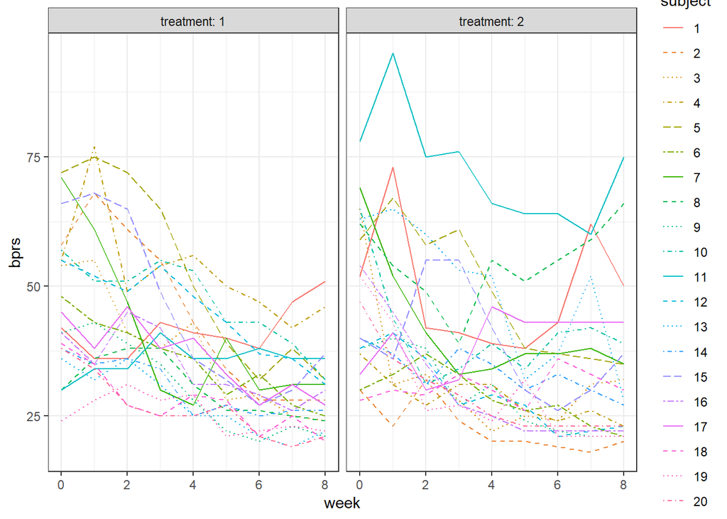

```r
Fitted <- fitted(mixedBPRS2)
BPRSL <- BPRSL %>% mutate(Fitted)

ggplot(BPRSL, aes(x = week, y = bprs, linetype = subject)) +
  geom_line() +
  scale_linetype_manual(values = rep(1:10, times=4)) +
  facet_grid(. ~ treatment, labeller = label_both) +
  theme_bw() +geom_line(aes(color=subject))
```

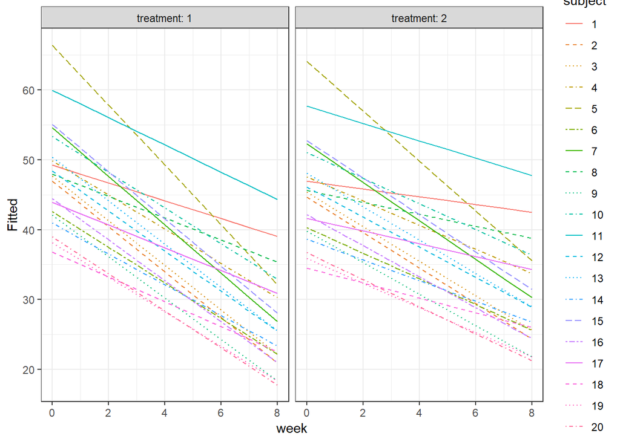

```r
ggplot(BPRSL, aes(x = week, y = Fitted, linetype = subject)) +
  geom_line() +
  scale_linetype_manual(values = rep(1:10, times=4)) +
  facet_grid(. ~ treatment, labeller = label_both) +
  theme_bw() +geom_line(aes(color=subject))
```

In these graphs we can see the negative effect of week on bprs, and that there’s not much difference between treatments. The fitted values include random effects, taking into account the variability within individuals across the weeks.